# Practical Coding Exercises in Machine Learning in R

Keaan Amin

Last Modified: 6th May 2021

# Purpose of this Series

- Learn Basic Functions in R [Week 1]
- Building your First Models in ML Week 2
- Visualise, Improve and Optimise your Models [Week 3]
- Develop Models on New Data Top to Toe [Week 4]

# Getting Started [before the session to be completed]

1. Install the Latest Base Package of R from below:

http://www.r-project.org/

2. Install Rstudio (if comfortable operating + projecting R plots at the command line - omit this step):

https://rstudio.com/products/rstudio/download/#download

3. Review the Introduction to R Video - Dr Skorupska

# Getting Help Once Live

1. Ask Google - Stackoverflow - lots of solutions
2. Ask R for help ?help(package=“stats”)
3. Package Documentation - Google
4. Google and use StackOverflow.com

# What’s R?

- A free language for statistical dataset analysis
- Enormous graphical capabilities through well-supported packages
- Interpretative language so commands are typed without requiring to build complete programmes
- Well-supported and documented modular add-on packages (16,000!) - across Stats, ML and ComputerBio
- Less learning -> more doing -> more problem-solving.

# How is it different to Excel or stats programmes e.g. SPSS?

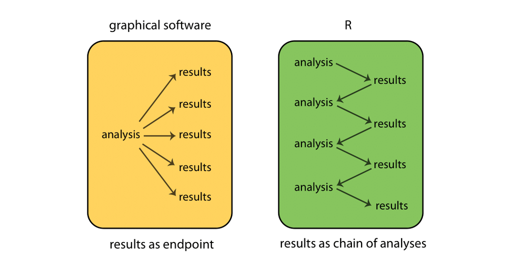

Lots of additional packages and resources to do more computational tasks. Shift through thousands of columns of data, visualise and adapt plots more quickly. Lots more creative capacity

# How does R work?

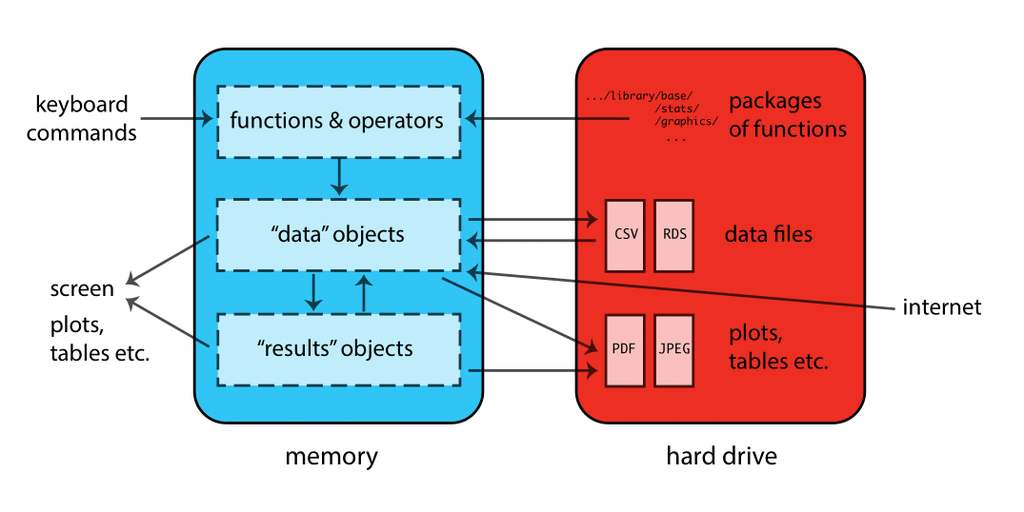

Apply our code as keyboard commands that interact with our workspace. Import data e.g. as txt or csv files that can be exported to use in other programmes. Produce plots.

# Major Uses of R

[figure not shown]

[figure not shown]

[figure not shown]

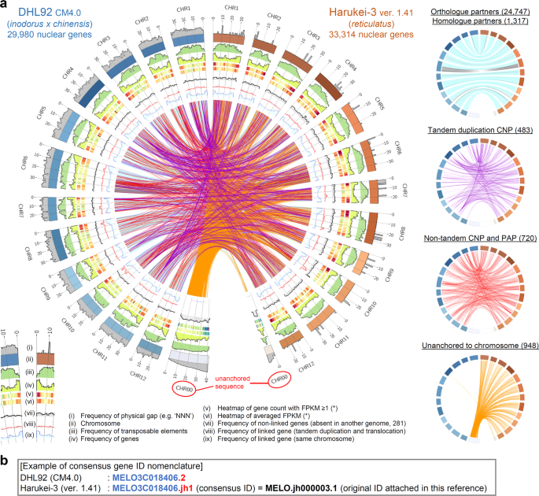

- Social Networks
- Major News Corporations
- Sports and Politics
- Academia

# Machine Learning

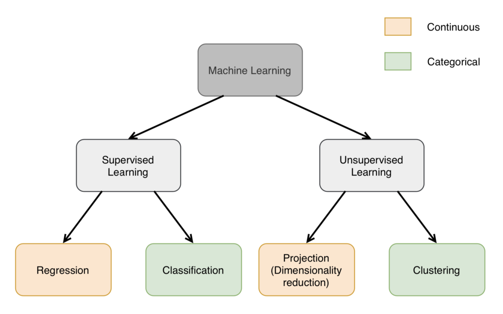

ML

# Install Packages

```r
# hashtags(#) denote a comment
# install.packages("caret")
# install.packages("ggplot2")
```

Load in our packages

```r
# library(ggplot2)
```

# Exercise 1 - Data Structures

Most commonly data is brought into R by txt and csv files:

```r
# You can fetch your WORKING directory as follows
getwd()
```

```
## [1] "C:/Users/keaan/Documents"
```

```r
# Change to your local directory - in my case it is as follows:
# setwd("C:/Users/keaan/OneDrive - Newcastle University/HLA - Virtual Elective/Week1/")
df <- read.csv("data.csv", sep=",",header=T,row.names = 1)
```

# Whistle stop syntax

We can operate from the command line like a calculator:

```r
5+15
```

```
## [1] 20
```

A *variable* is a letter or word that is assigned a value.

```r
x <- 10
x
```

```
## [1] 10
```

```r
y <- 5
y
```

```
## [1] 5
```

R will automatically add variables of the same type e.g. integers.

```r
y+x
```

```
## [1] 15
```

# Whistle stop Syntax

We can combine variables, in this characters to form a string:

```r
z <- c("ER","PR","HR")
z
```

```
## [1] "ER" "PR" "HR"
```

Essentially, a series of strings make an object and our object is df [dataframe]. In other words, strings make up columns.

# Search in a String / Column

We can search for a particular value in a string by sequence number:

```r
z[1]
```

```
## [1] "ER"
```

```r
z[1:3]
```

```
## [1] "ER" "PR" "HR"
```

```r
z[-1]
```

```
## [1] "PR" "HR"
```

We can ask if a particular value is in a string

```r
z=="PR"
```

```
## [1] FALSE  TRUE FALSE
```

```r
z[z=="PR"]
```

```
## [1] "PR"
```

# EXERCISE 2.1 - Data visualisation

Lets take a look at the breast data

```r
head(df)
```

```
##          diagnosis radius_mean texture_mean perimeter_mean area_mean
## 842302           M       17.99        10.38         122.80    1001.0
## 842517           M       20.57        17.77         132.90    1326.0
## 84300903         M       19.69        21.25         130.00    1203.0
## 84348301         M       11.42        20.38          77.58     386.1
## 84358402         M       20.29        14.34         135.10    1297.0
## 843786           M       12.45        15.70          82.57     477.1
##          smoothness_mean compactness_mean concavity_mean concave.points_mean
## 842302           0.11840          0.27760         0.3001             0.14710
## 842517           0.08474          0.07864         0.0869             0.07017
## 84300903         0.10960          0.15990         0.1974             0.12790
## 84348301         0.14250          0.28390         0.2414             0.10520
## 84358402         0.10030          0.13280         0.1980             0.10430
## 843786           0.12780          0.17000         0.1578             0.08089
##          symmetry_mean fractal_dimension_mean radius_se texture_se perimeter_se
```

[output cut: 41 more lines]

```r
df[1:5,1:5]
```

```
##          diagnosis radius_mean texture_mean perimeter_mean area_mean
## 842302           M       17.99        10.38         122.80    1001.0
## 842517           M       20.57        17.77         132.90    1326.0
## 84300903         M       19.69        21.25         130.00    1203.0
## 84348301         M       11.42        20.38          77.58     386.1
## 84358402         M       20.29        14.34         135.10    1297.0
```

SO we have a dataframe but exactly is composed of this?

```r
str(df)
```

```
## 'data.frame':    569 obs. of  32 variables:
##  $ diagnosis              : chr  "M" "M" "M" "M" ...
##  $ radius_mean            : num  18 20.6 19.7 11.4 20.3 ...
##  $ texture_mean           : num  10.4 17.8 21.2 20.4 14.3 ...
##  $ perimeter_mean         : num  122.8 132.9 130 77.6 135.1 ...
##  $ area_mean              : num  1001 1326 1203 386 1297 ...
##  $ smoothness_mean        : num  0.1184 0.0847 0.1096 0.1425 0.1003 ...
##  $ compactness_mean       : num  0.2776 0.0786 0.1599 0.2839 0.1328 ...
##  $ concavity_mean         : num  0.3001 0.0869 0.1974 0.2414 0.198 ...
##  $ concave.points_mean    : num  0.1471 0.0702 0.1279 0.1052 0.1043 ...
##  $ symmetry_mean          : num  0.242 0.181 0.207 0.26 0.181 ...
##  $ fractal_dimension_mean : num  0.0787 0.0567 0.06 0.0974 0.0588 ...
##  $ radius_se              : num  1.095 0.543 0.746 0.496 0.757 ...
##  $ texture_se             : num  0.905 0.734 0.787 1.156 0.781 ...
##  $ perimeter_se           : num  8.59 3.4 4.58 3.44 5.44 ...
```

[output cut: 18 more lines]

```r
with(df, table(diagnosis))
```

```
## diagnosis
##   B   M
## 357 212
```

# EXERCISE 2.2

1. How many patients are in the data?

# EXERCISE 2.2

```r
nrow(df)
```

```
## [1] 569
```

# EXERCISE 2.3 - Scatterplots

# EXERCISE 2.3

- Building graphs in R is like painting a picture.
- Elements are added one layer at a time + built up in levels

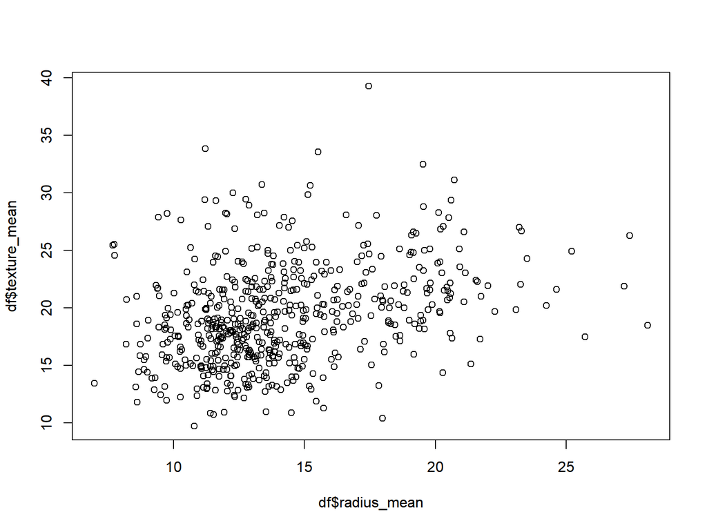

```r
plot(df$radius_mean,df$texture_mean)
```

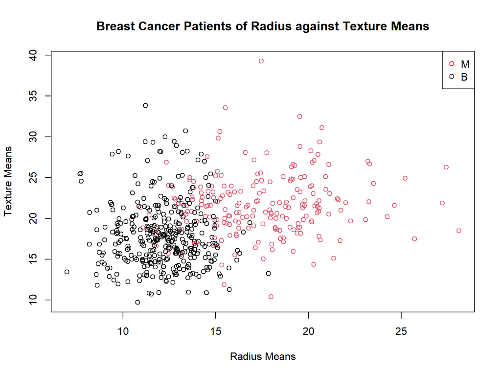

```r
plot(df$radius_mean,df$texture_mean,
col=as.factor(df$diagnosis),
xlab="Radius Means",
ylab="Texture Means",
main="Breast Cancer Patients of Radius against Texture Means")
legend("topright",legend = c("M", "B"), pch=c(1,1), col=c("red","black"))
```

# Building our First - Histograms in Base R

Let’s see how our data across looks across one variable e..g perimeter mean

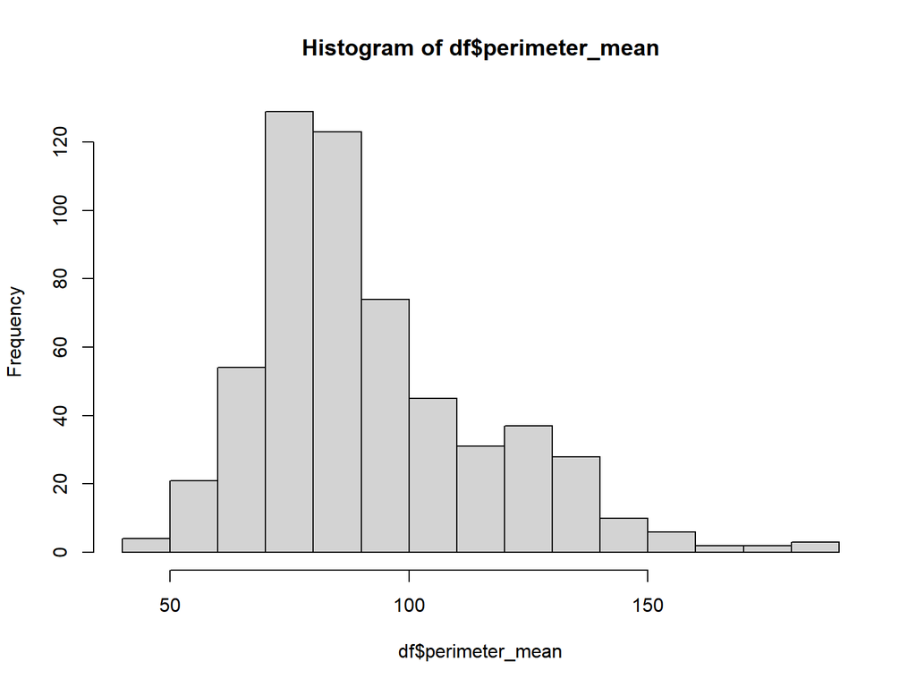

```r
hist(df$perimeter_mean)
```

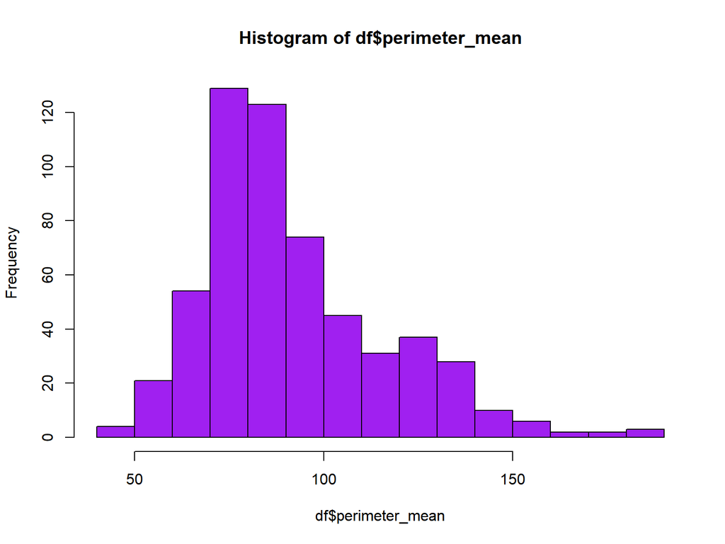

```r
hist(df$perimeter_mean,col="purple")
```

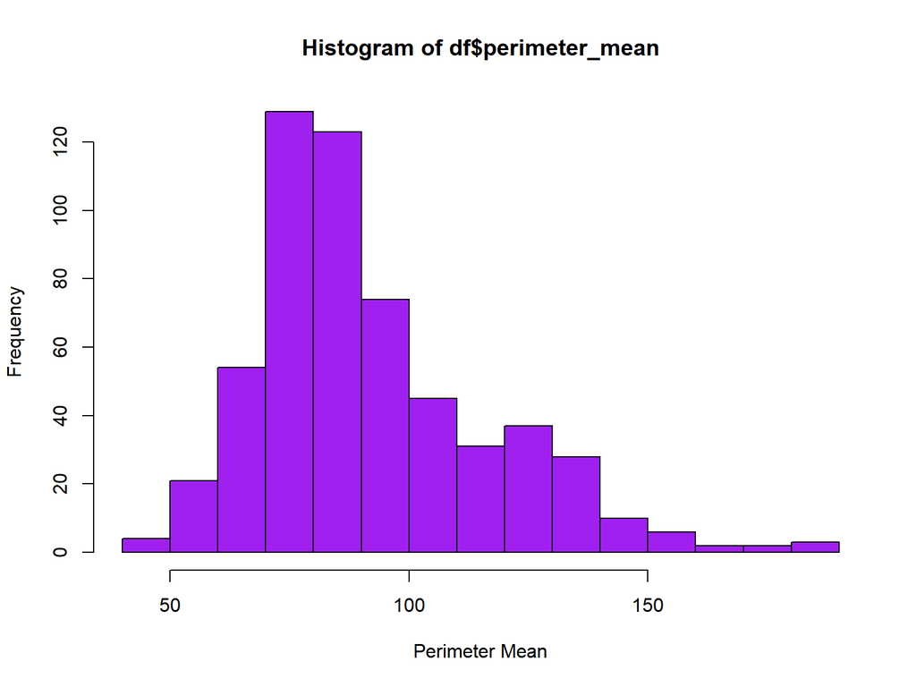

```r
hist(df$perimeter_mean,col="purple",xlab="Perimeter Mean")
```

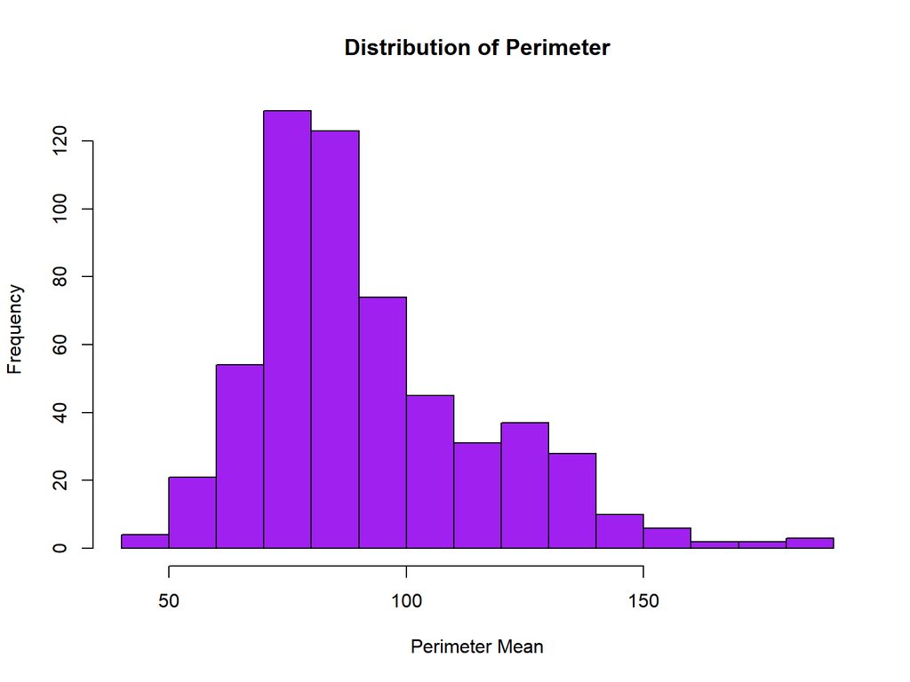

```r
hist(df$perimeter_mean,col="purple",xlab="Perimeter Mean",main="Distribution of Perimeter")
```

# Layering Plots using Base R

- We first need to separate our variables into two strings

```r
hist_b <- df$perimeter_mean[df$diagnosis=="B"]
hist_m <- df$perimeter_mean[df$diagnosis=="M"]
```

# How does this compare across both groups?

- Plot them over each other to create separation [don’t copy this!]

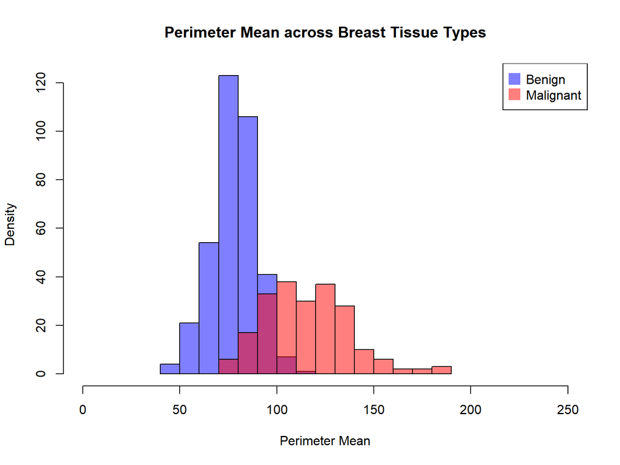

```r
# First distribution
plot.new()
hist(hist_b, breaks=10, xlim=c(0,250), col=rgb(0,0,1,0.5), xlab="Perimeter Mean",
     ylab="Density", main="Perimeter Mean across Breast Tissue Types" )

# Second with add=T to plot on top
hist(hist_m, breaks=10, xlim=c(0,250), col=rgb(1,0,0,0.5), add=T)

# Add legend
legend("topright", legend=c("Benign","Malignant"), col=c(rgb(0,0,1,0.5),
                                                         rgb(1,0,0,0.5)), pt.cex=2, pch=15 )
```

# How can we simplify plot making?

- Packages!

```r
library("ggplot2")
```

# Problems for Next Week!

- How can we distinguish between our variables to see which ones help to separate our two groups?
- What plots would you like to build to help us choose variables for our models?

# Next Week

- Further reading - caret (machine learning package) - http://www.rebeccabarter.com/blog/2017-11-17-caret_tutorial/, ggplot2 (graphical images package) - http://r-statistics.co/Complete-Ggplot2-Tutorial-Part1-With-R-Code.html,
- Shall release Week 2 Mini-Exercises this weekend - feature selection [step 1 of building our models!]
- No Formal Coding Homework for Week 1!

# Week 1 Questions

- How can we distinguish between our variables to see which ones help to separate our two groups?
- We could plot histograms for all our variables or use scatterplots
- We could alternatively use correlations

##Lets figure out our correlations

- First we need a dataframe of pure numbers so lets kick out the diagnosis [we made a pdata and rownames are still intact]

```r
dfint <- df[, !(colnames(df) %in% c("diagnosis"))]
```

- Correlations to two decimal places

```r
cormat <- round(cor(dfint),2)
```

- Let’s try out ggplot [a highly adaptable and well-supported graphics package to avoid layering our data + customise plots more easily]

We first need to do some data manipulation - we need all our data correlations into three columns.

```r
library(reshape2)
melted_cormat <- melt(cormat)
head(melted_cormat)
```

```
##               Var1        Var2 value
## 1      radius_mean radius_mean  1.00
## 2     texture_mean radius_mean  0.32
## 3   perimeter_mean radius_mean  1.00
## 4        area_mean radius_mean  0.99
## 5  smoothness_mean radius_mean  0.17
## 6 compactness_mean radius_mean  0.51
```

- Let’s make our first correlation plot

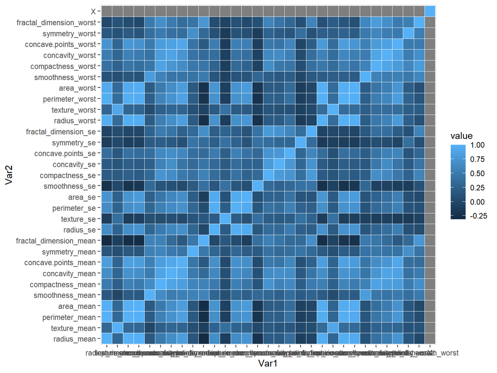

```r
library(ggplot2)
ggplot(data = melted_cormat, aes(x=Var1, y=Var2, fill=value)) +
  geom_tile(color = "white")
```

- Let’s add some colours and twist the labels

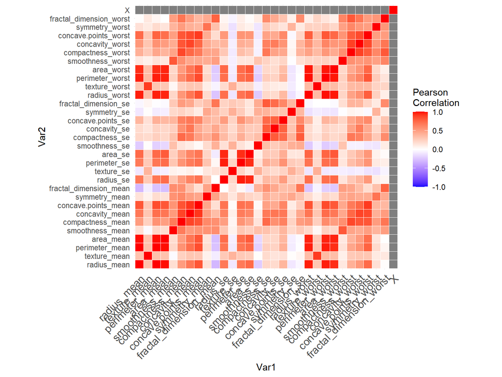

```r
ggplot(data = melted_cormat, aes(x=Var1, y=Var2, fill=value))+
  geom_tile(color = "white")+
  scale_fill_gradient2(low = "blue", high = "red", mid = "white",
                       midpoint = 0, limit = c(-1,1), space = "Lab",
                       name="Pearson\nCorrelation") +
  theme_minimal()+
  theme(axis.text.x = element_text(angle = 45, vjust = 1,
                                   size = 12, hjust = 1))+
  coord_fixed()
```

- If one or more variables are more correlated, this suggests one is depenent on the other.
- An algorithm will assume and estimate relationships based on independent variables.
- Based on the algorithm we selection, we may miss out on dependent details
- We are therefore at a risk of overfitting and to avoid this we can remove correlated variables. This may incur further repercussions…

# Week 2

- Building our first Classification Model
- Explanations of Various Algorithms at your figure tips!

# Feature Selection

- In other words what varaibles shall we use for our model
- We can use our expertise / experience as clinicians to pick out what is relevant.
- We can feature select by mathematical methods [Week 3]
- We can just take some variables, eyeballed from our correlations plot

```r
head(df)
```

```
##          diagnosis radius_mean texture_mean perimeter_mean area_mean
## 842302           M       17.99        10.38         122.80    1001.0
## 842517           M       20.57        17.77         132.90    1326.0
## 84300903         M       19.69        21.25         130.00    1203.0
## 84348301         M       11.42        20.38          77.58     386.1
## 84358402         M       20.29        14.34         135.10    1297.0
## 843786           M       12.45        15.70          82.57     477.1
##          smoothness_mean compactness_mean concavity_mean concave.points_mean
## 842302           0.11840          0.27760         0.3001             0.14710
## 842517           0.08474          0.07864         0.0869             0.07017
## 84300903         0.10960          0.15990         0.1974             0.12790
## 84348301         0.14250          0.28390         0.2414             0.10520
## 84358402         0.10030          0.13280         0.1980             0.10430
## 843786           0.12780          0.17000         0.1578             0.08089
##          symmetry_mean fractal_dimension_mean radius_se texture_se perimeter_se
```

[output cut: 41 more lines]

```r
df_filt <- df[, colnames(df) %in% c("radius_mean","texture_mean","perimeter_mean","area_mean","diagnosis")]
```

##Automatic Boxplots and Histograms

- Caret is an R package with a library of models - a virtual ToysRus - convienently contains plots as well

```r
require(caret)
```

```r
plot.new()
```

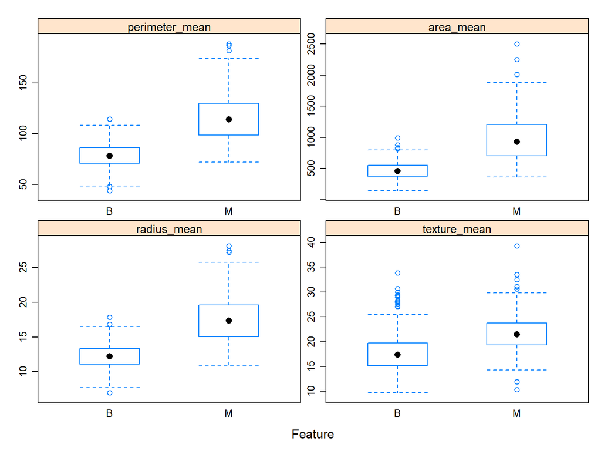

```r
featurePlot(x = df_filt[, 2:5],
            y = as.factor(df_filt$diagnosis),
            plot = "box",
            strip=strip.custom(par.strip.text=list(cex=.9)),
            scales = list(x = list(relation="free"),
                          y = list(relation="free")))
```

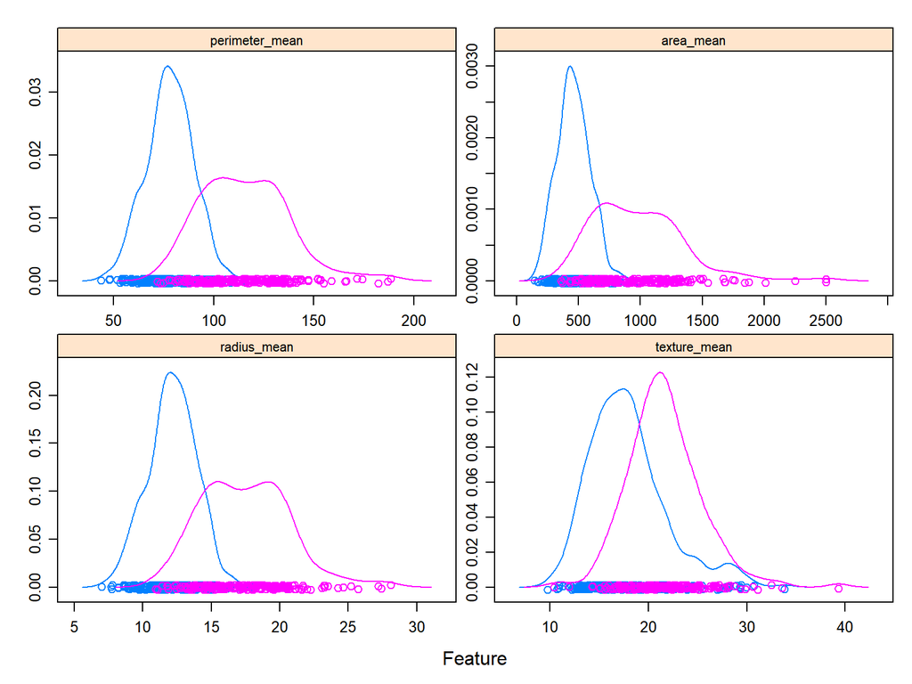

```r
featurePlot(x = df_filt[, 2:5],
            y = as.factor(df_filt$diagnosis),
            plot = "density",
            strip=strip.custom(par.strip.text=list(cex=.7)),
            scales = list(x = list(relation="free"),
                          y = list(relation="free")))
```